# Exercise 3: tapply and sapply

Zachary Harel

## Load state data

```r
data(state)
```

This data is stored in a slightly different way than other datasets we’ve used so far. Run this line of code to avoid later confusion.

```r
states <- as.data.frame(state.x77)
```

## 1. Average population, income, and area

What is the average population, income, and area of all 50 states in the `states` dataset?

```r
sapply(states[, c("Population", "Income", "Area")], mean)
```

```
## Population     Income       Area
##    4246.42    4435.80   70735.88
```

## 2. Average area by region

What is the average area of the states from different regions of the country? Hint: use the object `state.region` in your environment.

```r
tapply(states$Area, state.region, mean)
```

```
##     Northeast         South North Central          West
##      18141.00      54605.12      62652.00     134463.00
```

## 3. Histograms of every column

Plot a histogram for each column in the states data (Population, Income, Illiteracy etc.).

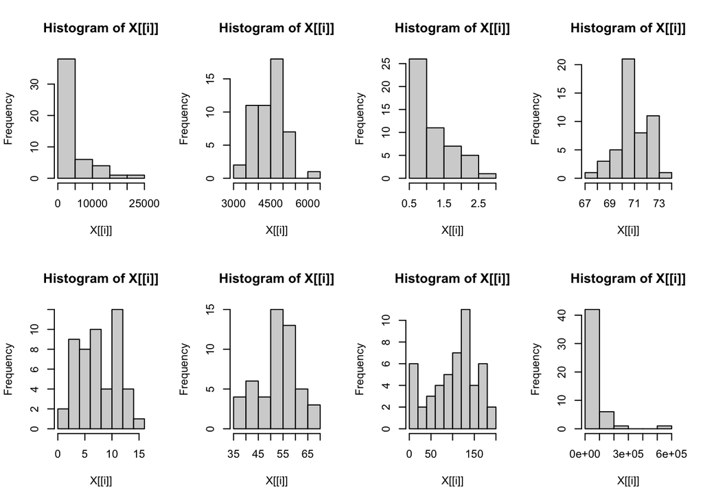

```r
par(mfrow = c(2, 4))
invisible(sapply(states, hist))
```

```r
par(mfrow = c(1, 1))
```

## 4. States to avoid

Let’s assume that we don’t want to live in a state with high illiteracy, high murder, and many freezing days; also assume that each of these factors contribute equally to our opinion: (Illiteracy * Murder * Frost) = undesirable. What 10 states should we avoid? Hint: use `prod()`, and maybe `order()`.

```r
undesirable <- apply(states[, c("Illiteracy", "Murder", "Frost")], 1, prod)
head(names(undesirable)[order(undesirable, decreasing = TRUE)], 10)
```

```
##  [1] "Alaska"         "New Mexico"     "South Carolina" "Georgia"
##  [5] "Kentucky"       "North Carolina" "Mississippi"    "Tennessee"
##  [9] "New York"       "Michigan"
```

```r
# so there actually is no "data below" I think?
```

## 6. Standardize the variables

Standardize all the variables in the states dataset and save your answer to a new dataframe, `states_standardized`. Hint: to standardize a variable, you subtract the mean and divide by the standard deviation (`sd`).

```r
states_standardized <- as.data.frame(sapply(states, function(v) (v - mean(v)) / sd(v)))
rownames(states_standardized) <- rownames(states)
```

## 7. Labeled histograms

Create a histogram again for each variable in the states data, but this time label each histogram with the variable names when you plot. Hint: instead of using apply to iterate over the columns themselves, you can often iterate over the column names with sapply.

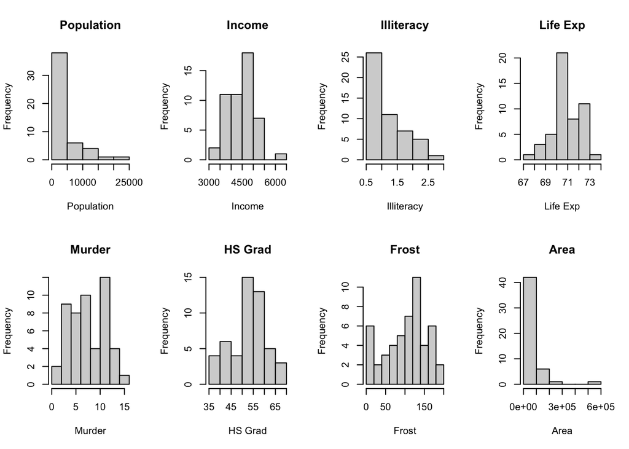

```r
par(mfrow = c(2, 4))
invisible(sapply(names(states),
                 function(name) hist(states[[name]], main = name, xlab = name)))
```

```r
par(mfrow = c(1, 1))
```